# hectorui: A web-based interactive scenario builder and visualization application for the Hector climate model

07 October 2020

# Statement of need

In a world of increasingly online, distributed, and diverse interdisciplinary research, there is a need to provide accessible and user-friendly interactive visualization tools that elucidate complex models and their output products. `hectorui` is an R Shiny web interface built to enhance the user experience for the simple global climate model Hector (Hartin et al. 2015), originally designed in C++ and later extended with an R interface. Before `hectorui`, Hector only had a command line-based interface available which requires fluency in C++ or R and a full understanding of Hector’s parameter space to run the model and create output. `hectorui` provides a fast, efficient solution that makes the model more accessible to a broader user base and offers enhanced functionality (Figure 1). This implementation allows users that may not be fluent in a programming language to interactively explore model scenarios and outputs in an easy to use, guided point and click interface.

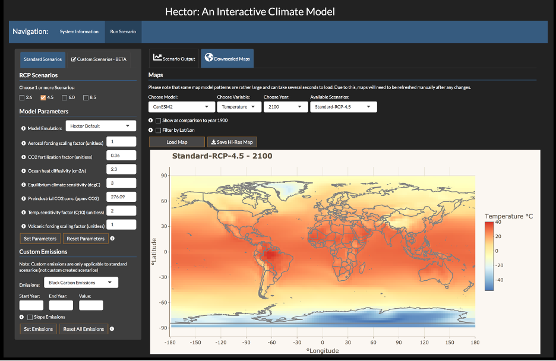

The map scenario interface to `hectorui` that allows the user to parameterize inputs and visualize run outputs interactively.

# Supporting software

The `hectorui` application was built in R Studio using the Shiny package. Shiny is a package for R that makes it easy to build and deploy interactive web apps straight from R (Chang et al. 2020). The built in components provide easy to use controls and layout functionality for building web applications without writing HTML.

The supporting software for `hectorui` is Hector, an open source, object-oriented, simple global climate carbon-cycle model. It runs essentially instantaneously while still representing the most critical global scale earth system processes and is one of a class of models heavily used for emulating complex climate models and uncertainty analyses (Hartin et al. 2016). Hector is also an input component for the Global Change Analysis Model (GCAM; Calvin et al. 2019). To run the model, a Hector core object is instantiated from an input file that contains a time series of greenhouse gas emissions. Hector comes equipped with input files, or scenarios, based on the Representative Concentration Pathways (RCP) 2.6 (Van Vuuren et al. 2011), 4.5 (Clarke et al. 2007; Thomson et al. 2011), 6.0 (Fujino et al. 2006), and 8.5 (Riahi, Grübler, and Nakicenovic 2007; Riahi et al. 2011). These scenarios were developed to cover the full range of potential emissions scenarios and were designed to meet research needs, such as output from human-Earth systems and sectoral models, impact analysis, and policy relevant research.

# Summary

`hectorui` provides the full functionality of Hector in a user-friendly web interface that can create Hector cores on demand to view any number of scenarios in parallel. Graphs of up to four output variables can be viewed simultaneously with each scenario represented as a time series. In addition to supporting Hector’s full functionality, the following describes some new capabilities that the `hectorui` offers. First, the user can configure Hector’s model input parameters to have the model emulate other well-known earth system models. This allows the user to seamlessly switch between models and see the changes reflected in the output. Another new feature provided are downscaled, gridded global maps of both temperature and precipitation that are dynamically generated from pattern files based on Hector and the other earth system models (Snyder et al. 2019). Lastly, in addition to the included canonical RCP scenarios the user can upload a set of custom emissions and run the model using these emissions to generate new time series results tailored to their specific research needs.

The ability to visualize and explore the model scenarios and data output for Hector allows both a broader user base to access Hector and the ability to rapidly explore scenarios and output. By creating user-friendly software that is simple to use which offers a generous set of pre-defined functionality, `hectorui` enhances Hector’s accessibility and equips the end user with the capability to focus on discovery and analysis instead of data processing, transformation, and time-consuming graph and chart development.

`hectorui` can be accessed via the web at the public domain https://jgcri.shinyapps.io/HectorUI/ or it can be installed and run locally as a standalone package (see https://github.com/JGCRI/hectorui to clone or fork for collaborative purposes). We provide an R vignette step-by-step tutorial for users to get started with `hectorui` which is accessible here: [Tutorial](https://jgcri.github.io/hectorui/articles/Tutorial.html).

# Acknowledgements

This research was supported in part by the U.S. Department of Energy, Office of Science, as part of research in MultiSector Dynamics, Earth and Environmental System Modeling Program. The Pacific Northwest National Laboratory is operated for DOE by Battelle Memorial Institute under contract DE-AC05-76RL01830. The authors also received support for this research through the U.S. Environmental Protection Agency, under Interagency Agreement DW08992459801. The views and opinions expressed in this paper are those of the authors alone.

# References

Calvin, Katherine, Pralit Patel, Leon Clarke, Ghassem Asrar, Ben Bond-Lamberty, Ryna Yiyun Cui, Alan Di Vittorio, et al. 2019. “GCAM V5. 1: Representing the Linkages Between Energy, Water, Land, Climate, and Economic Systems.” *Geoscientific Model Development (Online)* 12 (PNNL-SA-137098). https://doi.org/10.5194/gmd-12-677-2019.

Chang, Winston, Joe Cheng, JJ Allaire, Yihui Xie, and Jonathan McPherson. 2020. *Shiny: Web Application Framework for R*. https://CRAN.R-project.org/package=shiny.

Clarke, Leon, James Edmonds, Henry Jacoby, Hugh Pitcher, John Reilly, and Richard Richels. 2007. “Scenarios of Greenhouse Gas Emissions and Atmospheric Concentrations.”

Fujino, Junichi, Rajesh Nair, Mikiko Kainuma, Toshihiko Masui, and Yuzuru Matsuoka. 2006. “Multi-Gas Mitigation Analysis on Stabilization Scenarios Using Aim Global Model.” *The Energy Journal*, no. Special Issue# 3. https://doi.org/10.5547/ISSN0195-6574-EJ-VolSI2006-NoSI3-17.

Hartin, C. A., B. Bond-Lamberty, P. Patel, and A. Mundra. 2016. “Ocean Acidification over the Next Three Centuries Using a Simple Global Climate Carbon-Cycle Model: Projections and Sensitivities.” *Biogeosciences* 13 (15): 4329–42. https://doi.org/10.5194/bg-13-4329-2016.

Hartin, C. A., P. Patel, A. Schwarber, R. P. Link, and B. P. Bond-Lamberty. 2015. “A Simple Object-Oriented and Open-Source Model for Scientific and Policy Analyses of the Global Climate System – Hector V1.0.” *Geoscientific Model Development* 8 (4): 939–55. https://doi.org/10.5194/gmd-8-939-2015.

Riahi, Keywan, Arnulf Grübler, and Nebojsa Nakicenovic. 2007. “Scenarios of Long-Term Socio-Economic and Environmental Development Under Climate Stabilization.” *Technological Forecasting and Social Change* 74 (7): 887–935. https://doi.org/10.1016/j.techfore.2006.05.026.

Riahi, Keywan, V Krey, S Rao, V Chirkov, G Fischer, P Kolp, G Kindermann, N Nakicenovic, and P Rafai. 2011. “RCP-8.5: Exploring the Consequence of High Emission Trajectories.” *Climatic Change. Doi* 10: 1007. https://doi.org/10.1007/s10584-011-0149-y.

Snyder, Abigail, Robert Link, Kalyn Dorheim, Ben Kravitz, Ben Bond-Lamberty, and Corinne Hartin. 2019. “Joint Emulation of Earth System Model Temperature-Precipitation Realizations with Internal Variability and Space-Time and Cross-Variable Correlation: Fldgen V2. 0 Software Description.” *Plos One* 14 (10): e0223542. https://doi.org/10.1371/journal.pone.0223542.

Thomson, Allison M, Katherine V Calvin, Steven J Smith, G Page Kyle, April Volke, Pralit Patel, Sabrina Delgado-Arias, et al. 2011. “RCP4. 5: A Pathway for Stabilization of Radiative Forcing by 2100.” *Climatic Change* 109 (1-2): 77. https://doi.org/10.1007/s10584-011-0151-4.

Van Vuuren, Detlef P, Elke Stehfest, Michel GJ den Elzen, Tom Kram, Jasper van Vliet, Sebastiaan Deetman, Morna Isaac, et al. 2011. “RCP2. 6: Exploring the Possibility to Keep Global Mean Temperature Increase Below 2 c.” *Climatic Change* 109 (1-2): 95. https://doi.org/10.1007/s10584-011-0152-3.